# MT Colloquium Preparation

Joao Vitor Krieger | joaovitorkgs

março 09, 2025 | 19:38:55 | CET

```r
pacman::p_load(
  # Core Data Manipulation and Tidying
  dplyr,        # Data manipulation: filter, summarize, mutate, and more
  tidyr,        # Data tidying: pivot, handle missing values, reshape
  janitor,      # Clean messy data and create summary tables

  # Data Import and Export
  readr,        # Read flat files (CSV, TSV) into tibbles
  readxl,       # Read Excel files (.xls, .xlsx) into data frames
  basedosdados, # Access Brazilian public data via BigQuery
  httr,         # Perform HTTP requests for web API interactions
  archive,      # Extract files from compressed archives (.zip, .tar.gz)

  # Data Visualization
  ggplot2,      # Create customizable visualizations with grammar of graphics
  scales,       # Format axes and legends (percentages, currencies)
  viridis,      # Colorblind-friendly color palettes
  RColorBrewer, # Additional color palettes for plots
  gridExtra,    # Arrange multiple grid-based plots on a page

  # String Manipulation
  stringr,      # Simple and consistent string manipulation functions
  stringi,      # Advanced string manipulation with Unicode support

  # Date-Time Handling
  lubridate,    # Simplify date and time parsing and manipulation

  # Geographic and Spatial Data
  geobr,        # Access Brazilian geographic data (e.g., shapefiles)
  deflateBR,    # Deflate nominal Brazilian Reais using price indexes
  sf,           # Handle spatial/geographic data in R

  # Reporting and Tables
  gt,           # Create publication-quality tables
  stargazer,    # Generate regression tables in LaTeX/HTML/text formats

  # Machine Learning and Statistics
  caret,        # Comprehensive machine learning framework
  Metrics,      # Evaluate model performance (RMSE, MAE, etc.)
  glmnet,       # Regularized generalized linear models (Lasso, Ridge)
  earth,        # Multivariate Adaptive Regression Splines
  vip,          # Variable Importance Plots
  pdp,          # Partial Dependence Plots
  car,          # Companion to Applied Regression (diagnostic functions)
  DescTools,    # Tools for descriptive statistics
  rsample,      # Functions for resampling data

  # Econometrics and Time Series Analysis
  plm,          # Panel data analysis (fixed/random effects models)
  urca,         # Unit root and cointegration tests for time series
  forecast      # Time series forecasting functions and models
)
```

# 1 Introduction

The goal of my research consists of assessing the fiscal impact (in terms of tax revenue) of a greater adoption of electrical vehicles (EV) in Brazil, focusing exclusively on the shift from passenger cars with internal combustion engines (ICE) to plug-in/battery powered electric vehicles (BEV).

For that, I intend to calculate tax revenue scenarios based on two variables:

1. **Vehicle Stock:** total registered BEVs in a given moment. This variable will be used as input to calculate revenues from registration and annual vehicle tax.
2. **Energy Use:** vehicle stock and vehicle activity. This variable will be used as input to calculate revenue (or the loss thereof) from taxes on fuel.

To calculate the first variable, I intend to use historical data on the country’s fleet of passenger vehicles of all kinds and other relevant data (population size per state and city, income distribution on state level, vehicle prices) to estimate the current rates of BEV adoption in different states, and then use this information to extrapolate the data or run projections on how the BEV stock might grow in a time frame of 10-15 years.

To calculate second variable, I intend to use data on fuel sales and fuel consumption, as well as other information (such as average vehicle activity, measured in kilometers driven per year in different states). This variable will also be calculated with the first variable as input.

**This RMD file outlines the overall results I have achieved so far as part of my MT research and data work, which revolve mostly on calculating the first variable**. It also includes some contextual information which will be expanded as part of the final version of the thesis, as well as of the key data used, descriptive statistics, and results from the models attempted as of February 28.

The methods and results in this file draw mostly from these sources:

- OECD/ITF (2019), Tax Revenue Implications of Decarbonising Road Transport: Scenarios for Slovenia, OECD Publishing, Paris, https://doi.org/10.1787/87b39a2f-en/
- Boehmke, B., & Greenwell, B.M. (2019). Hands-On Machine Learning with R (1st ed.). Chapman and Hall/CRC. https://doi.org/10.1201/9780367816377
- Hyndman, R.J., & Athanasopoulos, G. (2018) Forecasting: principles and practice, 2nd edition, OTexts: Melbourne, Australia. [https://otexts.com/fpp2](https://otexts.com/fpp2/index.html).

# 2 Context

## 2.1 Stock of passenger cars

Brazil has had a significant growth of its BEV stock in the past 10 years, with a growth from 1600 registered BEVs in 2013 to more than 20,600 as of early 2025. While the number of other vehicles has also continued to grow, as indicated in the plot below, this growth of the BEV fleet could point to an early stage of a trend where these vehicles can take up a larger share of the country’s fleet.

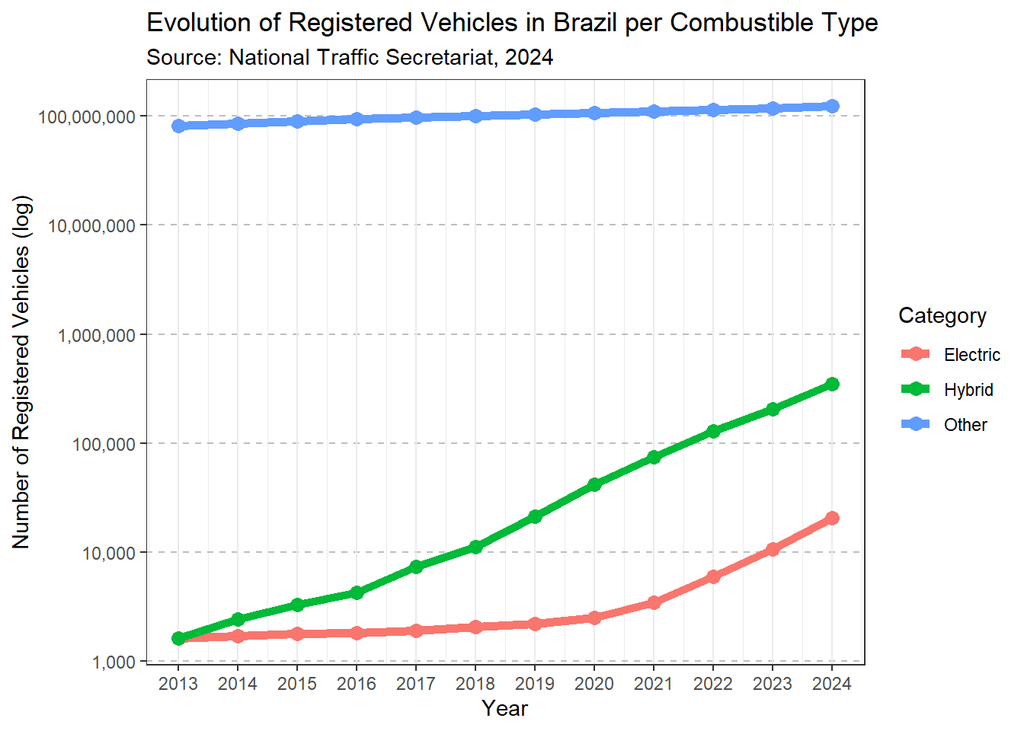

```r
setwd("C:/Users/joaov/Dropbox/R Assignments/master-thesis/")
yearly_results_agg_long <- read_csv("3_processed_data/fleet_yearly_agg_long.csv")

ggplot(yearly_results_agg_long, aes(x = as.integer(year), y = Count, color = Category)) +
  geom_line(linewidth = 2) +
  geom_point(size = 3) +
  theme_bw() +
  scale_x_continuous(breaks = seq(2013, 2024, by = 1)) +
  scale_y_continuous(
    trans = "log10",
    breaks = scales::trans_breaks("log10", function(x) 10^x), # Powers of 10
    labels = scales::comma # Readable labels with commas
  ) +
  theme(
    panel.grid.major.y = element_line(color = "gray", linetype = "dashed"), # Dashed grid lines for y-axis
    panel.grid.minor.y = element_blank() # Remove minor grid lines for clarity
  ) +
  labs(
    x = "Year",
    y = "Number of Registered Vehicles (log)",
    title = "Evolution of Registered Vehicles in Brazil per Combustible Type",
    subtitle = "Source: National Traffic Secretariat, 2024",
    color = "Category"
  )
```

## 2.2 Geographic Distribution of BEVs

The adoption of BEVs has remained heterogeneous among Brazilian cities and states. Factors such as income, level of urbanisation, population size and density, consumer preferences, and available infrastructure may play a role. The plots below illustrate different distributions of the number of BEVs among states, including the total fleet per state, BEV per capita, and share of BEVs as part of the total fleet of passenger cars).

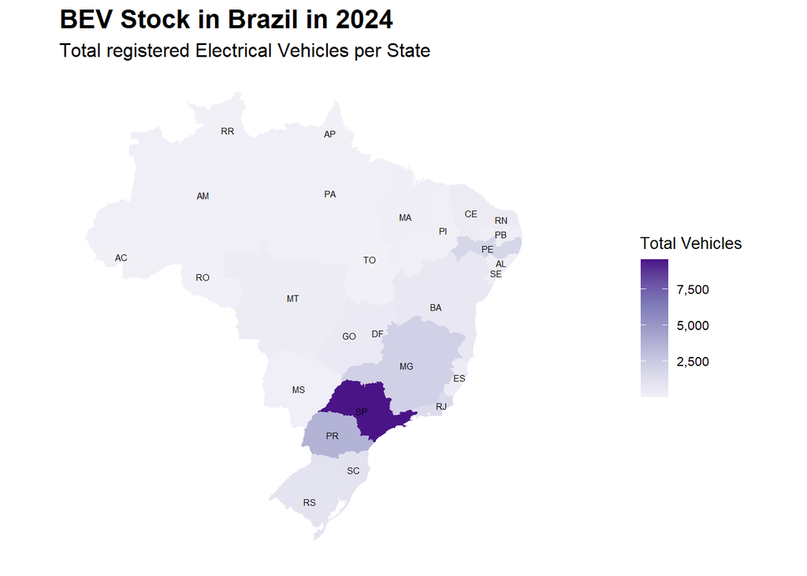

```r
setwd("C:/Users/joaov/Dropbox/R Assignments/master-thesis/")

fleet_electric_vehicles_all_years <- read_csv("3_processed_data/fleet_electric_vehicles_all_years.csv")
pop_city <- read_csv("1_raw_data/0_demographics/pop_city.csv")
state_df <- geobr::read_state(year = 2020,showProgress = FALSE)


# Create a string to use as common key to join the data frames
state_df$UF <- state_df$name_state %>%
  stringi::stri_trans_general("Latin-ASCII") %>%
  toupper()

# Join electric vehicle df with geographic info on the states
fleet_electric_vehicles_all_years <- fleet_electric_vehicles_all_years %>%
  left_join(state_df, by = "UF") %>%
  select(code_state, abbrev_state, name_state, code_region, name_region, geom, total_electric_vehicles, total_vehicles, percentage, year)

# Update variable name
fleet_electric_vehicles_all_years$name_state <- tolower(fleet_electric_vehicles_all_years$name_state)


# Adding State population to the data frame
state_pop <- pop_city %>%
  group_by(sigla_uf) %>%
  summarize(total_pop = sum(populacao)) %>%
  rename(abbrev_state = sigla_uf)

electric_vehicles_per_state <- fleet_electric_vehicles_all_years %>%
  filter(year == 2022) %>%
  left_join(state_pop, by = "abbrev_state")

electric_vehicles_per_state <- electric_vehicles_per_state %>%
  mutate(vehicle_per_capita = total_vehicles/total_pop,
         electric_vehicle_per_capita = total_electric_vehicles/total_pop)

# Convert the df to generate the map
electric_vehicles_per_state <- st_as_sf(electric_vehicles_per_state)

# Update the df to make the percentage column numeric
electric_vehicles_per_state$percentage_num <- as.numeric(sub("%", "", electric_vehicles_per_state$percentage))

# Create a variable for the theme in the plots
no_axis <- theme(axis.title=element_blank(),
                 axis.text=element_blank(),
                 axis.ticks=element_blank())

# Percentage of electric vehicles per State

options(scipen = 999)

ggplot() +
  geom_sf(data=electric_vehicles_per_state, aes(fill=total_electric_vehicles), color=NA, size=.15) +
  labs(
    title = "BEV Stock in Brazil in 2024",
    subtitle = "Total registered Electrical Vehicles per State",
    fill = "Total Vehicles") +
  geom_sf_text(data=electric_vehicles_per_state, aes(label=abbrev_state), size=2, color="black") +
  scale_fill_distiller(palette="Purples", name="Total Vehicles", direction = 1, labels = scales::comma_format()) +
  theme_minimal() +
  theme(
    plot.title = element_text(size = 16, face = "bold"),
    plot.subtitle = element_text(size = 12),
    legend.title = element_text(size = 10),
    legend.text = element_text(size = 8),
    panel.grid = element_blank(),
    plot.background = element_rect(fill = "#ffffff", color = NA)
  ) +
  no_axis
```

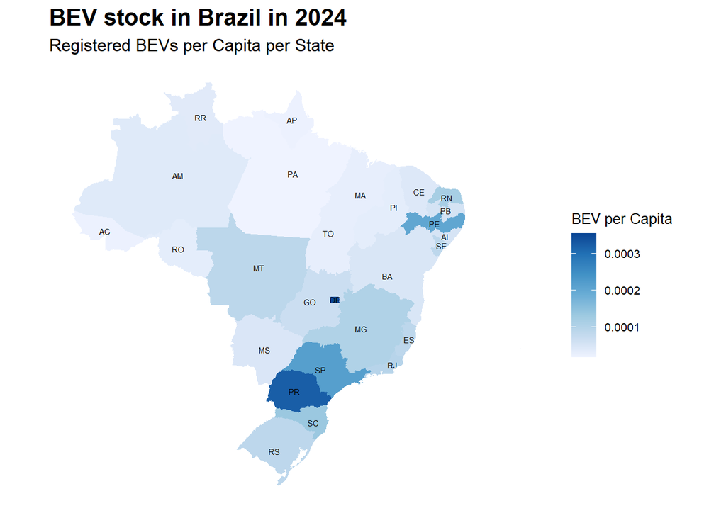

```r
# Total Vehicles per Capita
ggplot() +
  geom_sf(data=electric_vehicles_per_state, aes(fill=electric_vehicle_per_capita), color=NA, size=.15) +
  labs(
    title = "BEV stock in Brazil in 2024",
    subtitle = "Registered BEVs per Capita per State",
    fill = "Vehicles per Capita") +
  geom_sf_text(data=electric_vehicles_per_state, aes(label=abbrev_state), size=2, color="black") +
  scale_fill_distiller(palette="Blues", name="BEV per Capita", direction = 1) +
  theme_minimal() +
  theme(
    plot.title = element_text(size = 16, face = "bold"),
    plot.subtitle = element_text(size = 12),
    legend.title = element_text(size = 10),
    legend.text = element_text(size = 8),
    panel.grid = element_blank(),
    plot.background = element_rect(fill = "#ffffff", color = NA)
  ) +
  no_axis
```

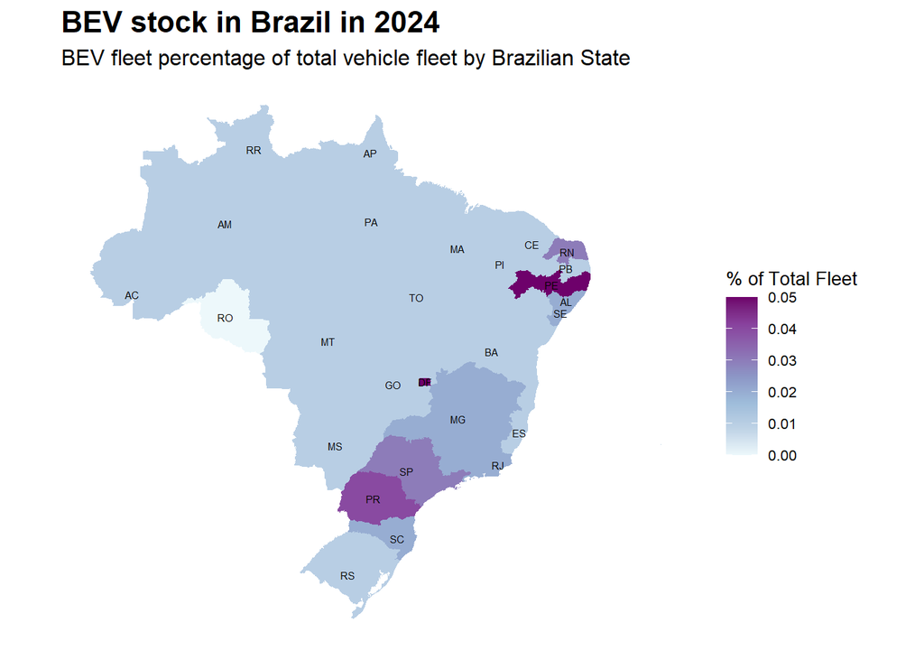

```r
# Share of BEVs as part of the total vehicle fleet
ggplot() +
  geom_sf(data=electric_vehicles_per_state, aes(fill=percentage_num), color=NA, size=.15) +
  labs(
    title = "BEV stock in Brazil in 2024",
    subtitle = "BEV fleet percentage of total vehicle fleet by Brazilian State",
    fill = "Vehicles per Capita") +
  geom_sf_text(data=electric_vehicles_per_state, aes(label=abbrev_state), size=2, color="black") +
  scale_fill_distiller(palette="BuPu", name="% of Total Fleet", direction = 1) +
  theme_minimal() +
  theme(
    plot.title = element_text(size = 16, face = "bold"),
    plot.subtitle = element_text(size = 12),
    legend.title = element_text(size = 10),
    legend.text = element_text(size = 8),
    panel.grid = element_blank(),
    plot.background = element_rect(fill = "#ffffff", color = NA)
  ) +
  no_axis
```

Finally, exploring the data on the share of BEVs from the total passenger car fleet in each state, a similar pattern emerges when comparing plots 3 and 4.

## 2.3 Tax revenue

Based on this data and the expectation that the BEV stock continues to growh, especially in the more populated, dense, and urbanized regions of the country, the future adoption of BEV in the place of ICE might represent a change in the tax revenue which currently is levied from fuel sales, vehicle stock and activity from conventional gasoline or hybrid vehicles.

To illustrate this, the plot below shows the trend of how the aggregate tax revenue from the past ten years related to fuel sales has changed and what trends there might be. In the timeframe examined, the only relevant external shock has been that of the COVID-19 pandemic, but the data on (nominal) tax revenue seems to be growing steadily.

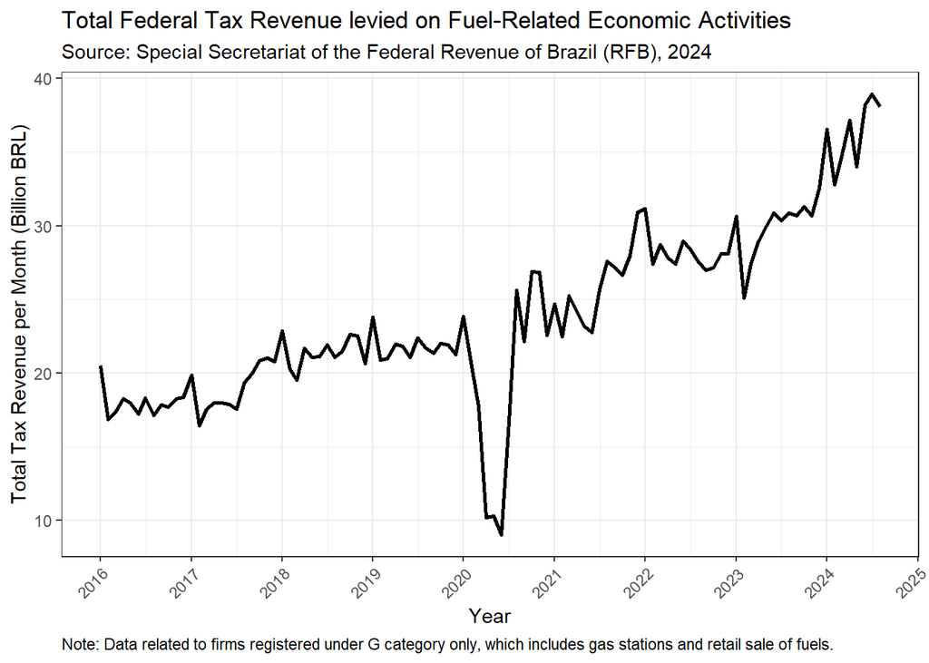

```r
setwd("C:/Users/joaov/Dropbox/R Assignments/master-thesis/")
federal_gasstation_fueltaxes <- read_csv("3_processed_data/taxrev_federal_gasstation_fueltaxes.csv")


ggplot(federal_gasstation_fueltaxes, aes(x = ano_mes_date,  y = fuel_taxes/1000000000)) +
  geom_line(linewidth = 1) +  # Line plot for each 'tipo_consumo'
  theme_bw() +                  # Clean theme
  scale_x_date(date_breaks = "1 year", date_labels = "%Y") +  # Show only the first month of each year
  scale_y_continuous(labels = scales::comma) +               # Format y-axis labels
  labs(
    x = "Year",
    y = "Total Tax Revenue per Month (Billion BRL)",
    title = "Total Federal Tax Revenue levied on Fuel-Related Economic Activities",
    subtitle = "Source: Special Secretariat of the Federal Revenue of Brazil (RFB), 2024",
    caption = "Note: Data related to firms registered under G category only, which includes gas stations and retail sale of fuels."
  ) +
  theme(
    axis.text.x = element_text(angle = 45, hjust = 1),  # Tilt x-axis labels
    plot.caption = element_text(hjust = 0))
```

With climate change as a backdrop and other factors that influence the Brazilian market for ICEs and BEVs — such as technology changes and the industry’s convergence to BEVs (Dumas and Dugoua, 2024), the effects of the 2024 tax reform, and potential shifts on consumer preferences — this trend on fuel sales and usage of fossil fuels may behave differently in the future.

# 3 Data used

## 3.1 Overview

All data used has been obtained from publicly available data from Brazilian official sources, including:

- National Traffic Secretariat (2024): fleet size per vehicle type (monthly data on city level).
- Special Secretariat of the Federal Revenue of Brazil (RFB): income distribution and tax revenue.
- Peixoto (2024): average vehicle prices by vehicle/fuel type (monthly data on national level).
- Base dos Dados (2024): demographic and geographic data, including population size per city and state.

The data frames loaded below are already the product of the project’s pipeline, including data scraping or downloading, cleaning and organizing for the purpose of this analysis.

```r
setwd("C:/Users/joaov/Dropbox/R Assignments/master-thesis/")

# Loading the data frames

fleet_2013_2024_clean <- read_csv("./3_processed_data/fleet_2013_2024_id_clean.csv")
price_df              <- read_csv("./3_processed_data/fipe_price_monthly_trends_deflated.csv")
income_data_wide_uf   <- read_csv("./3_processed_data/income_data_wide_uf.csv")

# Further transformation for the models

## Organizing population data and adding months

months <- fleet_2013_2024_clean %>%
  arrange(date) %>%
  distinct(date) %>%
  mutate(months_nr = row_number())

fleet_df <- fleet_2013_2024_clean %>%
  mutate(ev_pc        = electric / populacao,
         ff_pc        = (gasoline+diesel)/populacao,
         log_electric = log(electric),
         log_ff       = log(gasoline+diesel),
         log_pop      = log(populacao)) %>%
  filter(log_electric >= 0) %>%
  left_join(months, by="date")

fleet_df_b_city <- fleet_df %>%
  left_join(price_df, by = "date")

fleet_df_b_uf <- fleet_df %>%
  left_join(price_df, by = "date") %>%
  group_by(sigla_uf, date, months_nr) %>%
  summarize(diesel     = sum(diesel),
            ethanol    = sum(ethanol),
            gasoline   = sum(gasoline),
            other      = sum(other),
            electric   = sum(electric),
            gas        = sum(gas),
            population = sum(populacao))

## Adding price information and grouping by state
fleet_df_b_uf <- fleet_df %>%
  left_join(price_df, by = "date") %>%
  group_by(sigla_uf, date, year, month, months_nr) %>%
  summarize(diesel     = sum(diesel),
            ethanol    = sum(ethanol),
            gasoline   = sum(gasoline),
            other      = sum(other),
            electric   = sum(electric),
            gas        = sum(gas),
            population = sum(populacao),
            mean_gas   = mean(mean_price_gasoline),
            mean_hyb   = mean(mean_price_hybrid),
            mean_ev    = mean(mean_price_electric),
            median_gas = mean(median_price_gasoline),
            median_hyb = mean(median_price_hybrid),
            median_ev  = mean(median_price_electric),
            min_gas    = mean(min_price_gasoline),
            min_hyb    = mean(min_price_hybrid),
            min_ev     = mean(min_price_electric)) %>%
  mutate(ff_pc        = (gasoline+diesel)/population,
         log_ff       = log(gasoline+diesel),
         log_pop      = log(population))

## Adding income distribution data
fleet_df_c <- fleet_df_b_uf %>%
  left_join(income_data_wide_uf, by = c("year", "sigla_uf")) %>%
  drop_na()
```

## 3.2 Descriptive statistics

### 3.2.1 BEV stock and population size

The table below has a summary of the data frame combining population size (“`populacao`”) on city level with the existing fleet of passenger cars by fuel type.

```r
fleet_2013_2024_clean <- fleet_2013_2024_clean %>%
  mutate(id_municipio = as.character(id_municipio))

stargazer(as.data.frame(fleet_2013_2024_clean),
          title="Table 1: Summary statistics of data on pop. size and vehicle stock",
          column.sep.width = "15pt",
          digits=0,
          type = "html")
```

**Table 1: Summary statistics of data on pop. size and vehicle stock**

| Statistic | N | Mean | St. Dev. | Min | Max |
| --- | --- | --- | --- | --- | --- |
| diesel | 635,231 | 1,349 | 7,380 | 0 | 663,368 |
| ethanol | 635,231 | 7,414 | 61,157 | 0 | 5,581,980 |
| gasoline | 635,231 | 8,528 | 64,009 | 2 | 7,772,206 |
| other | 635,231 | 504 | 2,618 | 0 | 220,580 |
| electric | 635,231 | 5 | 123 | 0 | 24,337 |
| gas | 635,231 | 3 | 78 | 0 | 11,027 |
| month | 635,231 | 6 | 4 | 1 | 12 |
| year | 635,231 | 2,018 | 3 | 2,013 | 2,022 |
| populacao | 635,231 | 37,372 | 219,602 | 771 | 12,396,372 |

Exploring the data visually, I find that population has a clear positive correlation with the BEV fleet size, though this may be somewhat obvious.

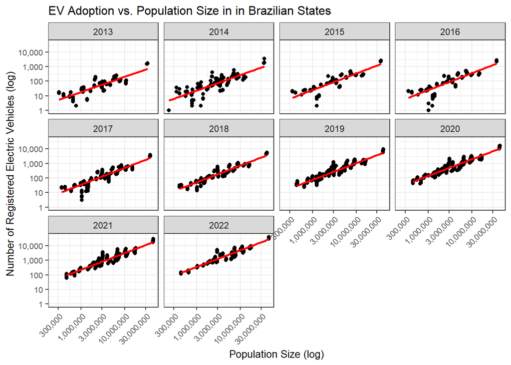

```r
ggplot(data = fleet_df_c, aes(x=population, y=electric)) +
  geom_point() +
  geom_smooth(method = "lm", se = FALSE, color = "red") + # Add linear regression line
  ggtitle("EV Adoption vs. Population Size in in Brazilian States")+
  theme_bw() +
  ylab("Number of Registered Electric Vehicles (log)") +
  xlab("Population Size (log)") +
  scale_x_continuous(trans = "log10", labels = scales::comma) + # Log scale for x-axis with meaningful labels
  scale_y_continuous(trans = "log10", labels = scales::comma) +  # Log scale for y-axis with meaningful labels
  facet_wrap(~year, nrow = 3, ncol = 4)  +
  theme(
    plot.title = element_text(size = 12),
    axis.title = element_text(size = 10),
    axis.text = element_text(size = 8),
    axis.text.x = element_text(angle = 45, hjust = 1)
  )
```

### 3.2.2 Price information

I have obtained a table with monthly prices of all vehicles being commercialized (new or used) in Brazil in a given month and year, from 2013 to 2022. The primary data is produced by FIPE, a research foundation that maintains a database on car prices to use as a parameter for individual transactions and valuation of any given car. I obtained this data from a secondary source (Peixoto, 2022), which scraped data from FIPE’s website and made it publicly available.

By grouping data based on each model’s fuel source (e.g. battery, gasoline, ethanol or hybrid), I have obtained mean, median, minimum and maximal prices, as well as the number of models available in a given month and year.

```r
stargazer(as.data.frame(price_df),
          title="Table 2: Summary statistics of data on vehicle price",
          column.sep.width = "3pt",
          digits=0,
          type = "html")
```

**Table 2: Summary statistics of data on vehicle price**

| Statistic | N | Mean | St. Dev. | Min | Max |
| --- | --- | --- | --- | --- | --- |
| mean_price_gasoline | 116 | 196,492 | 19,433 | 164,623 | 249,224 |
| mean_price_hybrid | 116 | 69,614 | 4,499 | 63,109 | 78,855 |
| mean_price_electric | 116 | 243,486 | 92,751 | 164,907 | 459,098 |
| median_price_gasoline | 116 | 2,951 | 663 | 2,133 | 4,342 |
| median_price_hybrid | 116 | 18,734 | 5,334 | 12,009 | 28,140 |
| median_price_electric | 116 | 163,384 | 49,276 | 83,052 | 233,627 |
| min_price_gasoline | 116 | 2,951 | 663 | 2,133 | 4,342 |
| min_price_hybrid | 116 | 18,734 | 5,334 | 12,009 | 28,140 |
| min_price_electric | 116 | 163,384 | 49,276 | 83,052 | 233,627 |
| max_price_gasoline | 116 | 6,853,602 | 1,286,591 | 4,936,365 | 8,956,361 |
| max_price_hybrid | 116 | 285,361 | 66,348 | 217,772 | 431,224 |
| max_price_electric | 116 | 445,466 | 405,115 | 164,907 | 1,497,071 |
| nr_models_gasoline | 116 | 2,047 | 599 | 1,181 | 3,375 |
| nr_models_hybrid | 116 | 804 | 404 | 260 | 1,708 |
| nr_models_electric | 116 | 9 | 14 | 1 | 63 |

When plotting the data, BEV prices and BEV stock seem to have some degree of correlation, suggesting that more BEVs are bought as more affordable vehicles are available in the Brazilian market. However, the data points are oddly spread in the plot, as I do not have an explanation for these two clusters that appear in the plot bellow.

Note: each data point in the plot represents the price of the cheapest BEV model (“`min_price_electric`”) available in the Brazilian market in a given month, and the BEV stock size in the corresponding month.

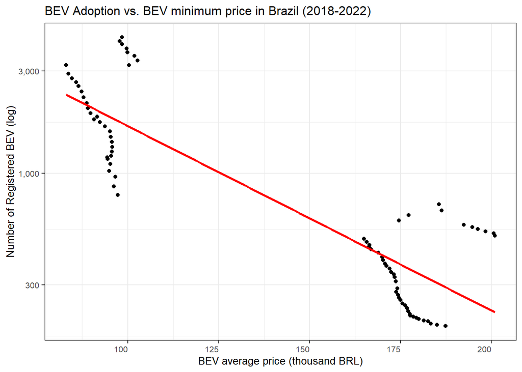

```r
fleet_df_c %>%
  filter(year > 2015) %>%
  group_by(date, year) %>%
  summarize(
    ev_price = mean(min_ev)/1000,
    electric = mean(electric)) %>%
  ggplot(aes(x=ev_price, y=electric)) +
  geom_point() +
  geom_smooth(method = "lm", se = FALSE, color = "red") + # Add linear regression line
  labs(
    title = "BEV Adoption vs. BEV minimum price in Brazil (2018-2022)",
  ) +
  theme_bw() +
  ylab("Number of Registered BEV (log)") +
  xlab("BEV average price (thousand BRL)") +
  scale_x_continuous(labels = scales::comma) + # Log scale for x-axis with meaningful labels
  scale_y_continuous(trans = "log10", labels = scales::comma) +
  theme(
    plot.title = element_text(size = 12),
    axis.title = element_text(size = 10),
    axis.text = element_text(size = 8),
    axis.text.x = element_text(angle = 0, hjust = 1)
  )
```

Exploring the yearly average prices for the most affordable models in the Brazilian market shows a trend in which prices are becoming cheaper as time passes.

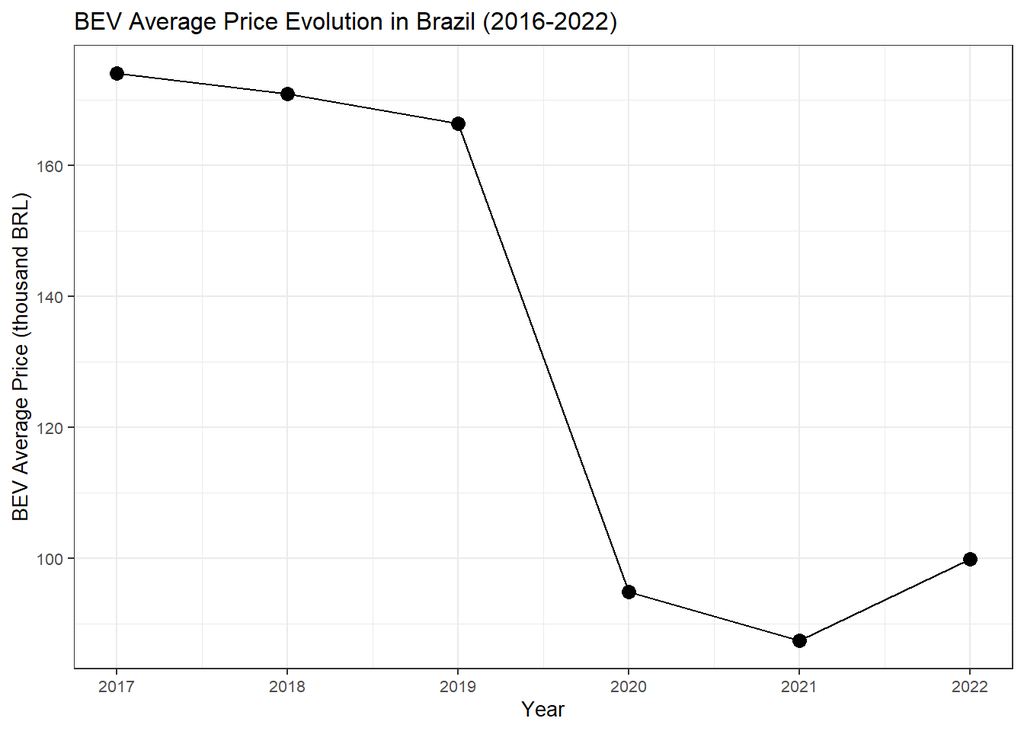

```r
fleet_df_c %>%
  filter(year > 2016) %>%
  group_by(year) %>%
  summarize(
    ev_price = mean(min_ev)/1000) %>%
  ggplot(aes(x = year, y = ev_price)) +
  geom_line() +
  geom_point(size = 3) +
  labs(
    title = "BEV Average Price Evolution in Brazil (2016-2022)",
    x = "Year",
    y = "BEV Average Price (thousand BRL)"
  ) +
  theme_bw() +
  scale_x_continuous(breaks = seq(2016, 2022, 1)) +
  scale_y_continuous(labels = scales::comma) +
  theme(
    plot.title = element_text(size = 12),
    axis.title = element_text(size = 10),
    axis.text = element_text(size = 8),
    axis.text.x = element_text(angle = 0, hjust = 0.5)
  )
```

When showing monthly data, the trend of price values behaves in an unexpected way between 2018 and 2019, which might demand some more careful revision of the available data at hand before plugging it into the models.

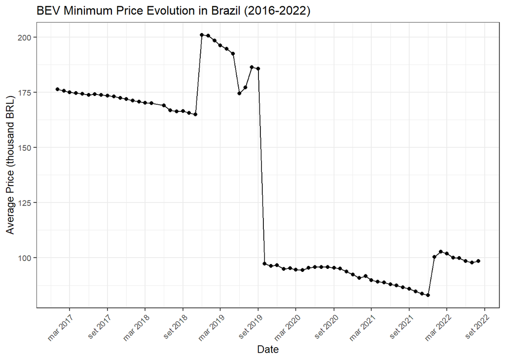

```r
fleet_df_c %>%
  filter(year > 2016) %>%
  mutate(month = floor_date(date, "month")) %>%
  group_by(month) %>%
  summarize(
    ev_price = mean(min_ev)/1000,
    electric = mean(electric)) %>%
  ggplot(aes(x = month, y = ev_price)) +
  geom_line() +
  geom_point() +
  labs(
    title = "BEV Minimum Price Evolution in Brazil (2016-2022)",
    x = "Date",
    y = "Average Price (thousand BRL)"
  ) +
  theme_bw() +
  scale_x_date(date_breaks = "6 months", date_labels = "%b %Y") +
  scale_y_continuous(labels = scales::comma) +
  theme(
    plot.title = element_text(size = 12),
    axis.title = element_text(size = 10),
    axis.text = element_text(size = 8),
    axis.text.x = element_text(angle = 45, hjust = 1)
  )
```

### 3.2.3 Income Information

For data on income, I used data published by the Brazilian national treasury on income distribution. The original data set lists yearly data on different kinds of taxable income classes per income percentile. I have adjusted the values to show deflated BRL, and used only the bottom 10th percentile, the median, and the top 90 and 100 percentiles.

```r
stargazer(as.data.frame(income_data_wide_uf),
          title="Table 3: Summary statistics of data on income distribution",
          column.sep.width = "3pt",
          digits=0,
          type = "html")
```

**Table 3: Summary statistics of data on income distribution**

| Statistic | N | Mean | St. Dev. | Min | Max |
| --- | --- | --- | --- | --- | --- |
| year | 297 | 2,018 | 3 | 2,013 | 2,023 |
| avg_taxable_income_10 | 297 | 9,958 | 3,656 | 0 | 21,422 |
| avg_taxable_income_50 | 297 | 40,577 | 8,062 | 27,499 | 74,918 |
| avg_taxable_income_90 | 297 | 122,053 | 28,799 | 75,343 | 262,539 |
| avg_taxable_income_100 | 297 | 547,757 | 101,275 | 364,797 | 891,392 |
| sum_taxable_income_10 | 297 | 135 | 394 | 0 | 3,900 |
| sum_taxable_income_50 | 297 | 573 | 1,554 | 18 | 14,814 |
| sum_taxable_income_90 | 297 | 1,763 | 4,831 | 47 | 46,332 |
| sum_taxable_income_100 | 297 | 9,053 | 25,892 | 218 | 237,644 |

When visualizing the data, the scatterplot below suggests that average taxable income of the richest percentile also seems to have a correlation with number of registered BEVs in a given month. This suggests that acquiring an BEV seems to be inaccessible for most of the population.

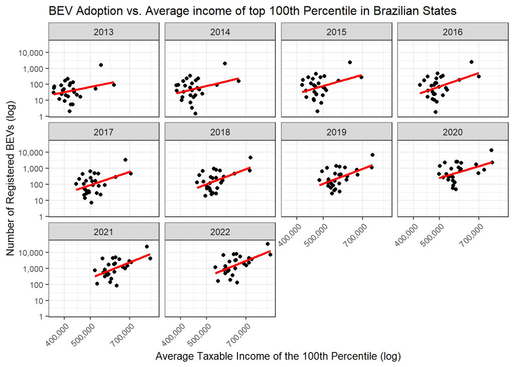

```r
fleet_df_c %>%
  group_by(year, sigla_uf) %>%
  summarize(
    avg_taxable_income_100 = mean(avg_taxable_income_100),
    electric = mean(electric)) %>%
  ggplot(aes(x=avg_taxable_income_100, y=electric)) +
  geom_point() +
  geom_smooth(method = "lm", se = FALSE, color = "red") + # Add linear regression line
  ggtitle("BEV Adoption vs. Average income of top 100th Percentile in Brazilian States")+
  theme_bw() +
  ylab("Number of Registered BEVs (log)") +
  xlab("Average Taxable Income of the 100th Percentile (log)") +
  scale_x_continuous(trans = "log10", labels = scales::comma) + # Log scale for x-axis with meaningful labels
  scale_y_continuous(trans = "log10", labels = scales::comma) +  # Log scale for y-axis with meaningful labels
  facet_wrap(~year, nrow = 3, ncol = 4) +
  theme(
    plot.title = element_text(size = 12),
    axis.title = element_text(size = 10),
    axis.text = element_text(size = 8),
    axis.text.x = element_text(angle = 45, hjust = 1)
  )
```

This correlation is not clear when looking into the average income for the 50th percentile (median). The plots suggest a negative correlation.

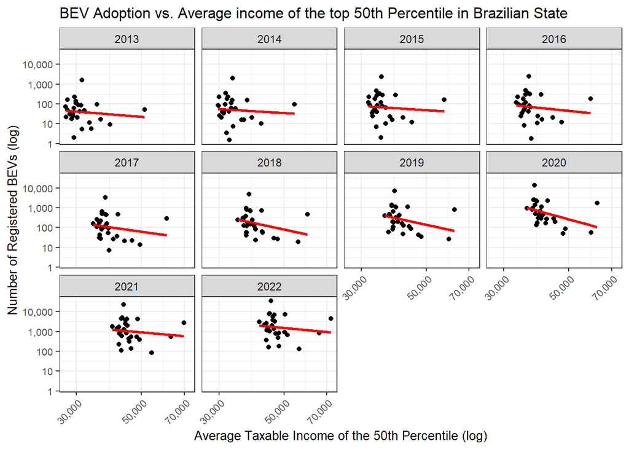

```r
fleet_df_c %>%
  group_by(year, sigla_uf) %>%
  summarize(
    avg_taxable_income_50 = mean(avg_taxable_income_50),
    electric = mean(electric)) %>%
  ggplot(aes(x=avg_taxable_income_50, y=electric)) +
  geom_point() +
  geom_smooth(method = "lm", se = FALSE, color = "red") + # Add linear regression line
  ggtitle("BEV Adoption vs. Average income of the top 50th Percentile in Brazilian State")+
  theme_bw() +
  ylab("Number of Registered BEVs (log)") +
  xlab("Average Taxable Income of the 50th Percentile (log)") +
  scale_x_continuous(trans = "log10", labels = scales::comma) + # Log scale for x-axis with meaningful labels
  scale_y_continuous(trans = "log10", labels = scales::comma) +  # Log scale for y-axis with meaningful labels
  facet_wrap(~year, nrow = 3, ncol = 4)+
  theme(
    plot.title = element_text(size = 12),
    axis.title = element_text(size = 10),
    axis.text = element_text(size = 8),
    axis.text.x = element_text(angle = 45, hjust = 1)
  )
```

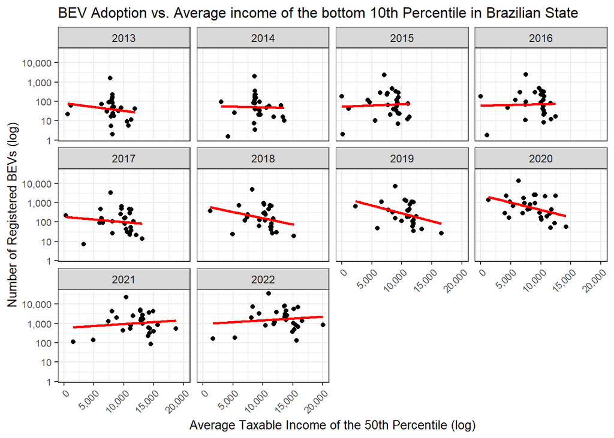

```r
# Also not true for the bottom 10 percentile

fleet_df_c %>%
  group_by(year, sigla_uf) %>%
  summarize(
    avg_taxable_income_10 = mean(avg_taxable_income_10),
    electric = mean(electric)) %>%
  ggplot(aes(x=avg_taxable_income_10, y=electric)) +
  geom_point() +
  geom_smooth(method = "lm", se = FALSE, color = "red") + # Add linear regression line
  ggtitle("BEV Adoption vs. Average income of the bottom 10th Percentile in Brazilian State")+
  theme_bw() +
  ylab("Number of Registered BEVs (log)") +
  xlab("Average Taxable Income of the 50th Percentile (log)") +
  scale_x_continuous(labels = scales::comma) + # Log scale for x-axis with meaningful labels
  scale_y_continuous(trans = "log10", labels = scales::comma) +  # Log scale for y-axis with meaningful labels
  facet_wrap(~year, nrow = 3, ncol = 4)+
  theme(
    plot.title = element_text(size = 12),
    axis.title = element_text(size = 10),
    axis.text = element_text(size = 8),
    axis.text.x = element_text(angle = 45, hjust = 1)
  )
```

# 4 Models

In order to project the BEV stock in Brazil in relation to future years by using past data, I have attempted to establish models that can correctly predict the information already at hand. The goal is to find good predictors to explain the growth in the BEV stock, which are statistically significant, and that have a logical mechanism that explains the relationship. Based on the coefficients found and the accuracy of the model, I will then create synthetic data which extrapolates the current BEV stock to the future years, which will then be used to examine the impact of electrifying the passenger vehicle fleet in Brazil on tax revenue.

The predictors chosen thus far and their rationale were the following:

- **Population size**: bigger cities and states are expected to have a more developed infrastructure, which would include charging infrastructure, as well as a bigger demand and offer for BEV.
- **Fossil fuel Vehicles** : instead of owning multiple cars, I would expect a gradual substitution of ICEs by BEVs as the stock of the latter increases.
- **Time**: due to recent trends, evolving consumer preferences, markets and available technologies, as well as a growing concern with climate change in recent years and the negative impacts of CO2 emitting cars, time (number of months passed) was included as a predictor.
- **Vehicle prices**: the first BEV models available in 2013 were twice as expensive as the cheapest models currently available. As BEVs become more affordable, the overall BEV stock is expected to increase.
- **Income**: in spite of recent BEVs models becoming gradually less expensive, the cost of the cheapest models still is significantly higher than that of ICEs. This would mean that cities and states with a higher average income of the top percentiles of the population would have a bigger BEV stock as well.

These predictors might also have some degree of multicollinearity. For example, larger cities and states tend to also be richer. Population growth and price changes are also correlated with the predictor related to time. This means that the predictors might introduce bias or have a limited capacity of explaining the increase in BEV in the models.

## 4.1 Linear regressions

The first and most simple models were simple linear regressions (OLS), where the BEV stock (the log-transformed number of registered BEVs in a given month in all Brazilian states) was regressed on population size and time. Another model includes the interaction between time and population, as well as with the number of other kinds of vehicles in the fleet.

```r
model1 <- lm(log(electric) ~ log(population) * months_nr,
             data = fleet_df_c)

model2 <- lm(log(electric) ~ log(population) * months_nr + log(min_ev) + log(mean_gas) + log(mean_hyb),
             data = fleet_df_c)

model3 <- lm(log(electric) ~ log(population) * months_nr + log(min_ev) + log(mean_gas) + log(mean_hyb) +
               log(avg_taxable_income_50) + log(avg_taxable_income_100),
             data = fleet_df_c)


stargazer(model1, model2, model3, type = "html",
          title=
            "Table 4: BEV stock regressed on population size, time, price & income (linear regression)",
          single.row= FALSE,
          column.labels =c("Model 1","Model 2", "Model 3", "Model 4"),
          covariate.labels=c("Population (log)",
                             "Months",
                             "Vehicle price - electric (log)",
                             "Vehicle price - gasoline (log)",
                             "Vehicle price - hybrid (log)",
                             "Avg. Income - 50th perc. (log)",
                             "Avg. Income - 100th perc. (log)",
                             "Vehicle price - hybrid (log)",
                             "Months : Population (log)"),
          keep.stat = c("rsq", "f"),
          notes.align = "l",
          dep.var.labels=c("EV stock (log)"))
```

**Table 4: BEV stock regressed on population size, time, price & income (linear regression)**

|  | *Dependent variable:* |  |  |
| --- | --- | --- | --- |
|  | EV stock (log) |  |  |
|  | Model 1 | Model 2 | Model 3 |
|  | (1) | (2) | (3) |
| Population (log) | 1.050*** | 1.093*** | 1.111*** |
|  | (0.023) | (0.022) | (0.023) |
| Months | 0.006 | 0.012** | 0.007 |
|  | (0.005) | (0.005) | (0.005) |
| Vehicle price - electric (log) |  | -0.465*** | -0.474*** |
|  |  | (0.082) | (0.082) |
| Vehicle price - gasoline (log) |  | 1.748*** | 1.864*** |
|  |  | (0.309) | (0.308) |
| Vehicle price - hybrid (log) |  | 0.943** | 0.735 |
|  |  | (0.480) | (0.479) |
| Avg. Income - 50th perc. (log) |  |  | 0.662*** |
|  |  |  | (0.104) |
| Avg. Income - 100th perc. (log) |  |  | -0.113 |
|  |  |  | (0.128) |
| Vehicle price - hybrid (log) | 0.002*** | 0.001** | 0.001*** |
|  | (0.0004) | (0.0003) | (0.0003) |
| Months : Population (log) | -12.044*** | -38.581*** | -43.196*** |
|  | (0.333) | (2.954) | (3.288) |
| R<sup>2</sup> | 0.867 | 0.881 | 0.883 |
| F Statistic | 6,485.506*** (df = 3; 2978) | 3,675.522*** (df = 6; 2975) | 2,802.532*** (df = 8; 2973) |
| *Note:* | p<0.1; p<0.05; p<0.01 |  |  |

**Interpretation:**

The above regression tables shows state-level data where the BEV stock is regressed on log-transformed population, months, average car prices per vehicle type and an interactions between population and time-related variable.

As for the effect of income — measured here as the annual average taxable income of the 50th and 100th top percentiles — in each state, the median average income seems to have a positive correlation, but the average income of the top earners in Brazilian states has no statistically significant effect, with an unexpected negative correlation.

When testing whether the models are able to predict past data, the line indicating fitted data seems to follow the actual observed data quite well:

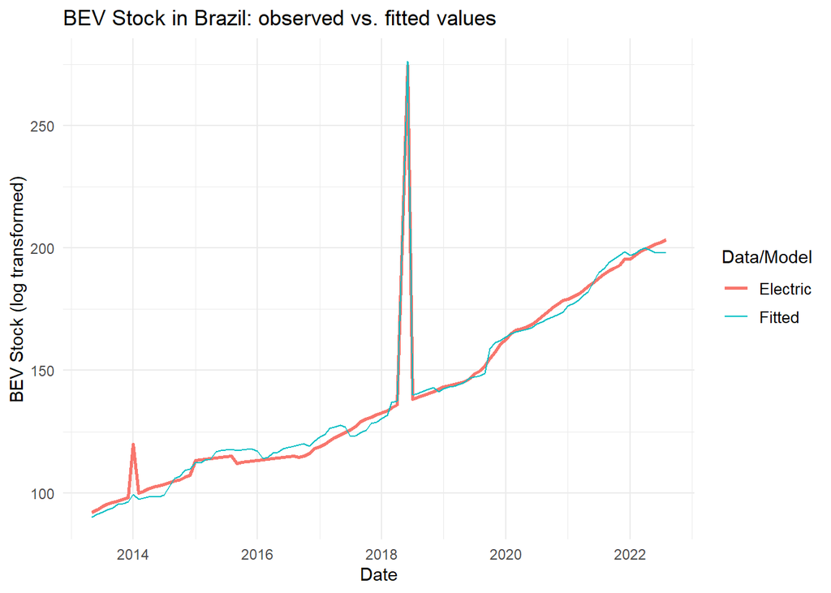

```r
# Add fitted values to the dataset
fleet_df_c$fitted_1 <- model1$fitted.values
fleet_df_c$fitted_2 <- model2$fitted.values
fleet_df_c$fitted_3 <- model3$fitted.values

fleet_df_models <- fleet_df_c %>%
  ungroup() %>%
  select(sigla_uf, date, year, month, electric, fitted_1, fitted_2, fitted_3) %>%
  group_by(date) %>%
  summarize(
    electric = sum(log(electric)),
    fitted_1 = sum(fitted_1),
    fitted_2 = sum(fitted_2),
    fitted_3 = sum(fitted_3),
  )

ggplot(fleet_df_models) +
  geom_line(aes(x = date, y = electric, color = "Electric"), size = 1) +
  geom_line(aes(x = date, y = fitted_3, color = "Fitted"), size = 0.5) +
  labs(
    title = "BEV Stock in Brazil: observed vs. fitted values",
    x = "Date",
    y = "BEV Stock (log transformed)",
    colour = "Data/Model"
  ) +
  theme_minimal() +
  theme(
    legend.title = element_text(size = rel(1)),
    legend.text = element_text(size = rel(0.9))
)
```

## 4.2 Panel Data and Fixed-Effects

As an improvement to the linear regressions above, the following regressions incorporate fixed effects for the used units of observations (i.e. states), in order to focus on variance within units and account for the natural and significant differences between states.

```r
panel_data <- pdata.frame(fleet_df_c, index = c("sigla_uf", "date"))

fe_model_1 <- plm(log(electric) ~ log(population) + as.factor(months_nr),
                  data  = panel_data,
                  model = "within")

fe_model_2 <- plm(log(electric) ~ log(population) + log(min_ev) + log(mean_gas) + log(mean_hyb) + as.factor(months_nr),
                  data  = panel_data,
                  model = "within")

fe_model_3 <- plm(log(electric) ~ log(population) + log(min_ev) + log(mean_gas) + log(mean_hyb) + log(avg_taxable_income_50) + log(avg_taxable_income_100) + as.factor(months_nr),
                  data  = panel_data,
                  model = "within")


stargazer(fe_model_1, fe_model_2, fe_model_3, type = "html",
          title = "Table 5: BEV stock regressed on population size, time, vehicle prices and income with panel data and fixed effects",
          single.row = FALSE,
          dep.var.labels = c("EV stock (log)"),
          covariate.labels=c("Population (log)",
                             "Vehicle price - electric (log)",
                             "Vehicle price - gasoline (log)",
                             "Vehicle price - hybrid (log)",
                             "Avg. Income - 50th perc. (log)",
                             "Avg. Income - 100th perc. (log)"),
          column.labels = c("Model 1", "Model 2", "Model 3"),
          keep.stat = c("rsq", "f"),
          notes.align = "l",
          omit = "as.factor\\(months_nr\\)[0-9]+",
          intercept.bottom = TRUE)
```

**Table 5: BEV stock regressed on population size, time, vehicle prices and income with panel data and fixed effects**

|  | *Dependent variable:* |  |  |
| --- | --- | --- | --- |
|  | EV stock (log) |  |  |
|  | Model 1 | Model 2 | Model 3 |
|  | (1) | (2) | (3) |
| Population (log) | 1.753*** | 1.753*** | 1.848*** |
|  | (0.060) | (0.060) | (0.058) |
| Vehicle price - electric (log) |  | -4.023*** | -5.373*** |
|  |  | (0.974) | (0.948) |
| Vehicle price - gasoline (log) |  | -2.029 | -1.927 |
|  |  | (3.673) | (3.554) |
| Vehicle price - hybrid (log) |  | 0.749 | 1.413 |
|  |  | (6.944) | (6.720) |
| Avg. Income - 50th perc. (log) |  |  | -0.504*** |
|  |  |  | (0.144) |
| Avg. Income - 100th perc. (log) |  |  | -2.226*** |
|  |  |  | (0.172) |
| R<sup>2</sup> | 0.929 | 0.929 | 0.933 |
| F Statistic | 336.817*** (df = 110; 2845) | 336.817*** (df = 110; 2845) | 355.039*** (df = 112; 2843) |
| *Note:* | p<0.1; p<0.05; p<0.01 |  |  |

**Interpretation:**

The regression with panel data and fixed-effects has a better performance, with the R² value in all three models being around 0.93. It also indicates an increased effect from population and vehicle prices, especially for the price of BEVs, when compared to the linear regressions with no fixed effects. The results from table 5 suggest that, on average, a 1% decrease on the average vehicle price for the cheapest BEV available on the market on a given month is associated to a 5.4% increase on the BEV stock.

As for the effect of income, the median average income seems to have a now a negative effect, as well as the average income of the top earners in each state. This is an unexpected effect of the correlation between income and BEV stock.

## 4.3 Regularized Regressions

A further step in the analysis was to regularize the estimate coefficients, to reduce variance and decrease out of sample error. The following code shows applications of the ridge regression, in which a tuning parameter (`lambda`) has been added to force correlated coefficients and less important predictors toward zero, thus reducing collinearity. Additionally, a Lasso (least absolute shrinkage and selection operator) penalty was also introduced, to push correlated coefficients and irrelevant predictors to zero, using automated feature selection.

For this section of analysis, additional features were included to the data set, such as mean, median and minimum prices for BEVs, hybrid and gasoline vehicles; the fleet size for vehicles of all engine/fuel types; as well as the log-transformed population size (`log_pop`) and size of the vehicle stock with combustion engines (`log_ff`), and the ratio of vehicles with combustion engines per capita (`ff_pc`).

The goal of using these methods is to identifying a model where the MSE (Mean Squared Error) is minimized. In this case, the MSE will be used to determine the statistical significance of the factors or predictors under study.

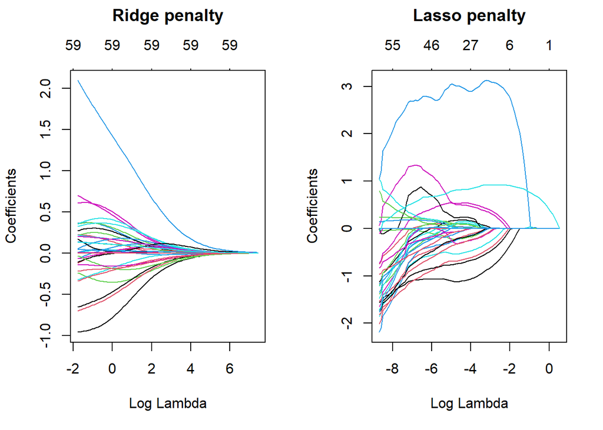

```r
# Create training  feature matrices
# we use model.matrix(...)[, -1] to discard the intercept

library(glmnet)

X <- modglmnetX <- model.matrix(log(electric) ~ ., fleet_df_c)[, -1]
Y <- log(fleet_df_c$electric)

# Ridge model
ridge <- glmnet(
  x = X,
  y = Y,
  alpha = 0
)

# Lasso model
lasso <- glmnet(
  x = X,
  y = Y,
  alpha = 1
)

par(mfrow = c(1, 2))
# plot ridge model
plot(ridge, xvar = "lambda", main = "Ridge penalty\n\n")

# plot lasso model
plot(lasso, xvar = "lambda", main = "Lasso penalty\n\n")
```

The plot above shows the coefficients’ value being pushed towards zero as the `lambda` value increases. However, differently from the examples in Boehmke & Greenwell (2019), where dashed lines were plotted for the `lambda` values with the smallest MSE and at one standard error of the minimum MSE, this model returns a `NULL` value for these `lambda` values:

```r
ridge$lambda.min
```

```r
ridge$lambda.1se
```

```r
lasso$lambda.min
```

```r
lasso$lambda.1se
```

This might mean that the algorithm was unable to determine an optimal regularization parameter for the data set being used, either because the model is not converging to any of the attempted `lambda` values, or because the multicollinearity among the predictors makes it difficult for the algorithm to determine the appropriate `lambda` value. Also, given the good performance of the previous linear regressions, it might mean that the model is overfitted, i.e. it performs well to explain the relationship between independent and dependent variables with the data existing, but it performs poorly with new data.

Following Boehmke & Greenwell (2019), a workaround to this was to use the **caret** package to automate the tuning process (i.e. chosing the parameters to optimize the model and find the lowest regularized MSE). The code output below shows the chosen `lambda` value, which penalizes the existing predictors; and the `alpha` value (which determines whether the **glmnet** package should perform a ridge (`alpha = 0`), lasso (`alpha = 1`) or elastic net (`0 < alpha < 1`) model.

```r
# for reproducibility
set.seed(123)

# grid search across
cv_glmnet <- train(
  x = X,
  y = Y,
  method = "glmnet",
  preProc = c("zv", "center", "scale"),
  trControl = trainControl(method = "cv", number = 10),
  tuneLength = 10
)

cv_glmnet$results %>%
  filter(alpha == cv_glmnet$bestTune$alpha, lambda == cv_glmnet$bestTune$lambda)
```

| alpha | lambda | RMSE | Rsquared | MAE | RMSESD | RsquaredSD | MAESD |
| --- | --- | --- | --- | --- | --- | --- | --- |
| 0.2 | 0.0007851819 | 0.3149129 | 0.9697393 | 0.2259752 | 0.0153205 | 0.002672532 | 0.01122672 |

```r
# predict number of electric vehicles on training data
pred <- predict(cv_glmnet, X)

# compute RMSE of transformed predicted
RMSE(exp(pred), exp(Y))
```

```
[1] 374.1919
```

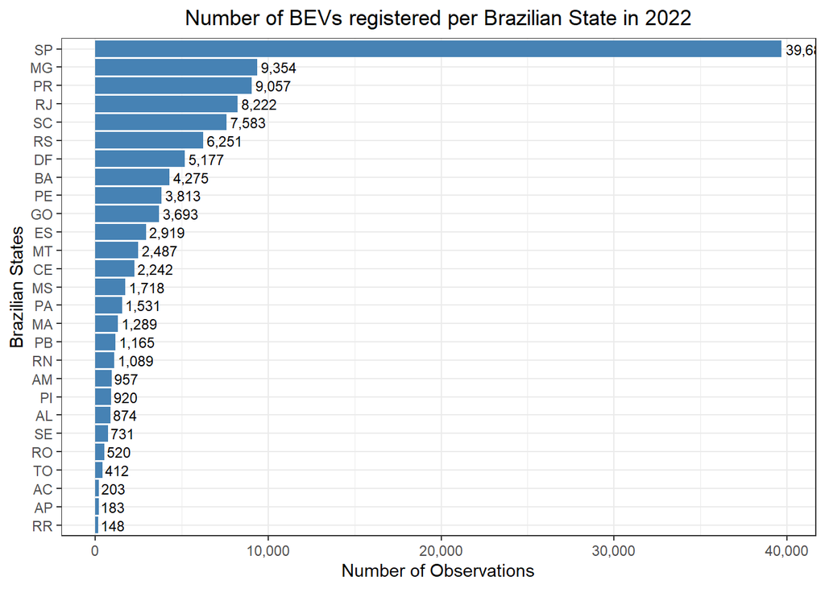

```r
fleet_df_c %>%
  select(year, sigla_uf, electric) %>%
  filter(year == 2022) %>%
  group_by(sigla_uf) %>%
  summarize(
    BEVs  = max(electric)
  ) %>%
  arrange((BEVs)) %>%
  mutate(sigla_uf = factor(sigla_uf, levels = sigla_uf)) %>%
  ggplot(aes(y = sigla_uf, x = BEVs)) +
  geom_bar(stat = "identity", fill = "steelblue") +
  geom_text(aes(label = comma(BEVs)), hjust = -0.1, size = 3) +
  scale_x_continuous(labels = comma) +
  ggtitle("Number of BEVs registered per Brazilian State in 2022") +
  xlab("Number of Observations") +
  ylab("Brazilian States") +
  theme_bw() +
  theme(plot.title = element_text(hjust = 0.5))
```

Lastly, the plot below shows the 20 variables with the greatest importance, as determined by the magnitude of the standardized coefficients.

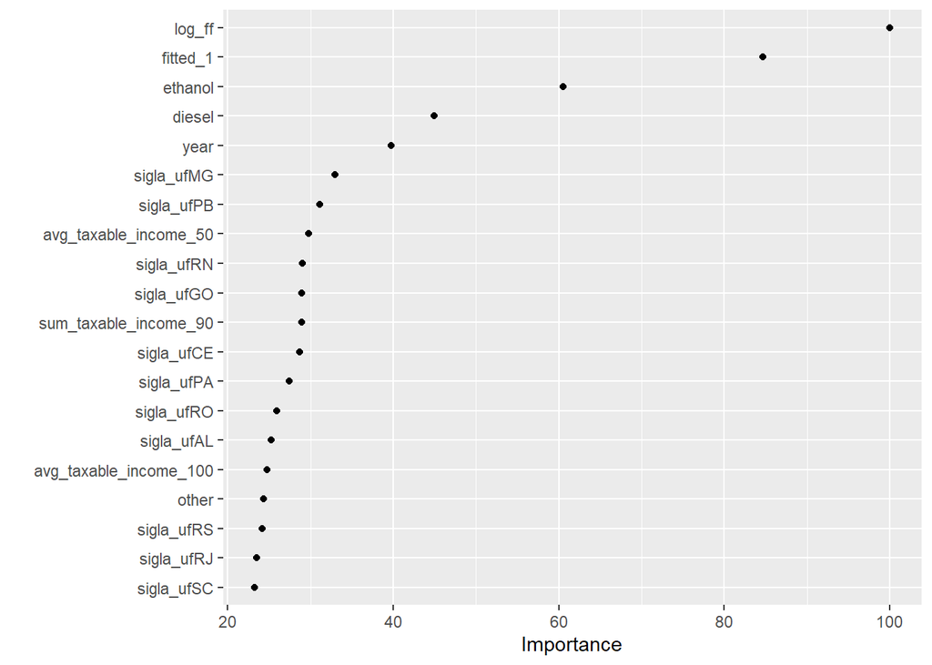

```r
vip(cv_glmnet, num_features = 20, geom = "point")
```

# 5 Forecasting

## 5.1 Time Series

First step was to test how well the model was able to predict past data. To do that, I have used the same linear regression models from the previous sections, but by transforming the dataframe in a time series object and using the `tslm` function of the **forecast** package.

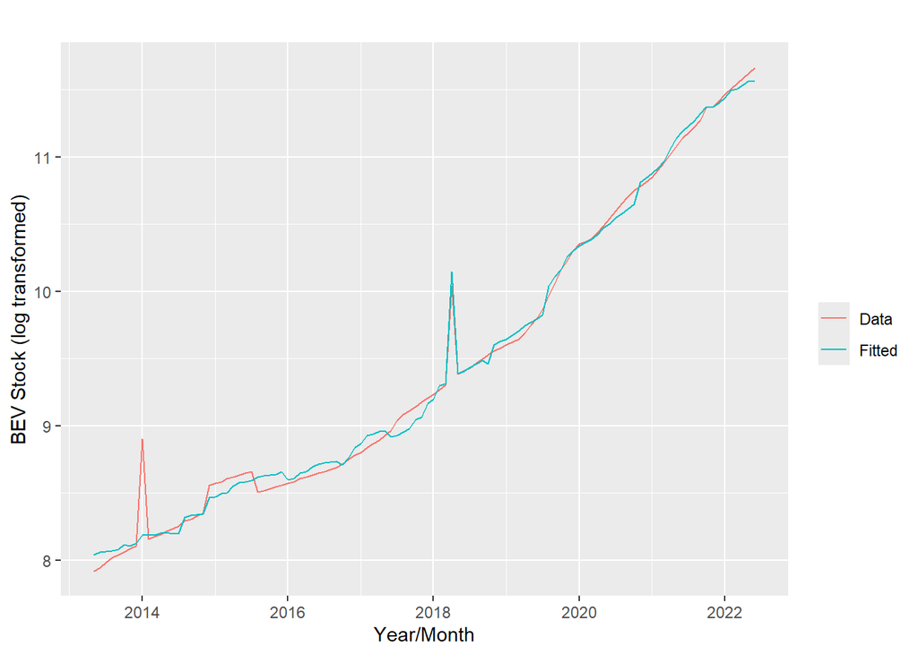

```r
fleet_df_ts <- fleet_df_c %>%
  ungroup() %>%
  select(sigla_uf, date, year, month, electric, population, min_ev, mean_gas, mean_hyb, avg_taxable_income_50, avg_taxable_income_100) %>%
  group_by(date) %>%
  summarize(
    electric                = sum(electric),
    population              = sum(population),
    min_ev                  = mean(min_ev),
    mean_gas                = mean(mean_gas),
    mean_hyb                = mean(mean_hyb),
    avg_taxable_income_50   = mean(avg_taxable_income_50),
    avg_taxable_income_100  = mean(avg_taxable_income_100),
    log_electric               = log(electric),
    log_population             = log(population),
    log_min_ev                 = log(min_ev),
    log_mean_gas               = log(mean_gas),
    log_mean_hyb               = log(mean_hyb),
    log_avg_taxable_income_50  = log(avg_taxable_income_50),
    log_avg_taxable_income_100 = log(avg_taxable_income_100)
  ) %>%
  mutate(
    electric   = if_else(date == as.Date("2018-06-01"), electric   / 2, electric),
    population = if_else(date == as.Date("2018-06-01"), population / 2, population)
  )

fleet_df_ts <- fleet_df_ts %>% arrange(date)

# Extract start year and month
start_year <- as.numeric(format(min(fleet_df_ts$date), "%Y"))
start_month <- as.numeric(format(min(fleet_df_ts$date), "%m"))


# Convert to a multivariate time series object
multivariate_ts <- ts(
  fleet_df_ts,
  start = c(start_year, start_month),
  frequency = 12
)

ts_model_1 <- tslm(log_electric ~
                   log_population *
                   date,
             data = multivariate_ts)


ts_model_2 <- tslm(log_electric ~
                   log_population *
                   date +
                   log_min_ev +
                   log_mean_gas +
                   log_mean_hyb,
             data = multivariate_ts)

ts_model_3 <- tslm(log_electric ~
                   log_population *
                   date +
                   log_min_ev +
                   log_mean_gas +
                   log_mean_hyb +
                   log_avg_taxable_income_50 +
                   log_avg_taxable_income_100,
             data = multivariate_ts)


ts_model_exp <- tslm(electric ~ trend, lambda = 0, data = multivariate_ts)

autoplot(multivariate_ts[,'log_electric'], series="Data") +
  autolayer(fitted(ts_model_3), series="Fitted") +
  xlab("Year/Month") + ylab("BEV Stock (log transformed)") +
  guides(colour=guide_legend(title=" "))
```

When forecasting using an exponential model from the time series regression, considering a horizon of about 7 years from the last date in the model:

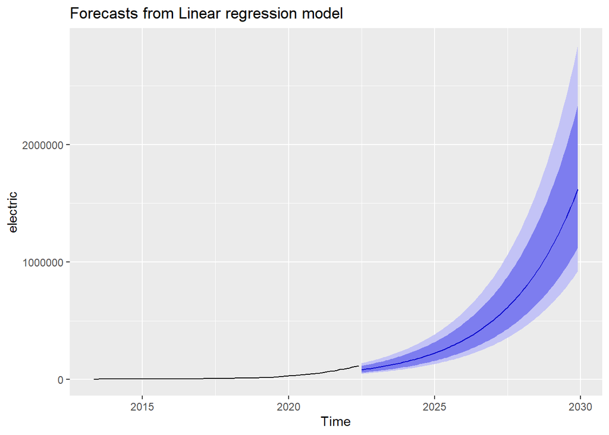

```r
h = 90
fcast <- forecast(ts_model_exp, h=h)

autoplot(fcast)
```

## 5.2 ARIMA

A different approach attempted was to forecast values using an ARIMA (acronym for “AutoRegressive Integrated Moving Average”) model, which aim to describe autocorrelations in the data and predict future outcome values based on the lagged values of $y_t$ and $\epsilon_t$ as predictors. For that purpose, the **forecast** package in R has been used.

```r
setwd("C:/Users/joaov/Dropbox/R Assignments/master-thesis/")

# Data preparation
fleet_2013_2024_id_clean <- read_csv("3_processed_data/fleet_2013_2024_id_clean.csv")


## Adding the variation on registered BEVs on a monthly basis to be able to use an ARIMA model

fleet_df <- fleet_df %>%
  arrange(id_municipio, date) %>%
  group_by(id_municipio) %>%
  mutate(new_electric = lag(electric, default = first(electric))) %>%
  ungroup()

fleet_df <- fleet_2013_2024_id_clean %>%
  mutate(date = floor_date(date, "month")) %>%
  group_by(year, date, sigla_uf, id_municipio,id_municipio_nome) %>%
  summarize(
    electric_vehicles = sum(electric),
    total_population = sum(populacao),
  )

fleet_df <- fleet_df %>%
  arrange(id_municipio, date) %>%
  group_by(id_municipio) %>%
  mutate(lag_electric = dplyr::lag(electric_vehicles)) %>%
  ungroup() %>%
  mutate(new_electric = electric_vehicles - lag_electric) %>%
  select(-lag_electric)

fleet_df$new_electric[is.na(fleet_df$new_electric)] <- 0

fleet_df_uf <- fleet_df %>%
  group_by(year, date, sigla_uf) %>%
  summarize(
    EVs_total = sum(electric_vehicles),
    EVs_delta = sum(new_electric))

fleet_df_BR <- fleet_df %>%
  group_by(year, date) %>%
  summarize(
    EVs_total = sum(electric_vehicles),
    EVs_delta = sum(new_electric))
```

For these forecasting models, I have also added “`EVs_delta`” as a new variable, in order to attempt an ARIMA model based both on the total cumulative number of registered BEVs in the country in a given month, but also on the variation from on month to another.

The plots below show how this variable behaved in different states, emphasizing the regional differences and the influence of some predictors (e.g. income distribution, population size) as discussed in the previous sections.

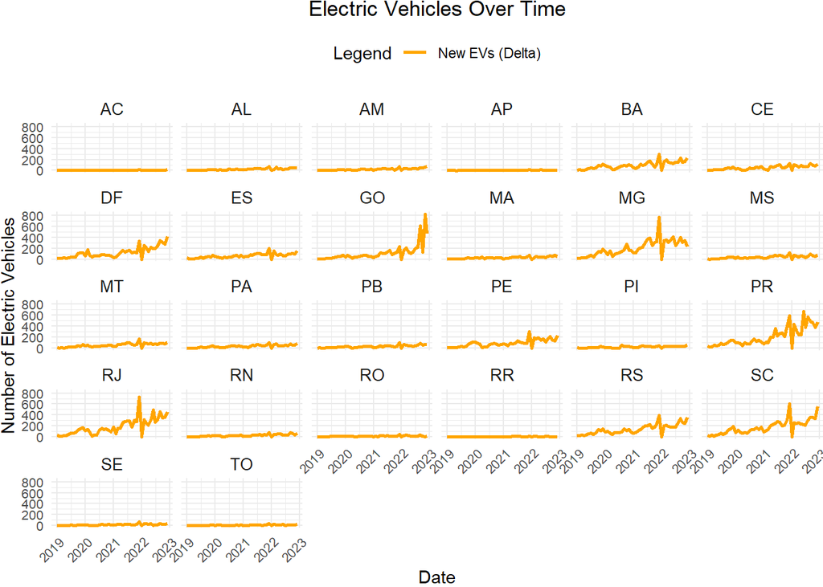

```r
fleet_df_uf %>%
  filter(year > 2018, sigla_uf != "SP") %>%
  ggplot(aes(x = date)) +
  geom_line(aes(y = EVs_delta, color = "New EVs (Delta)"), size = 1) +
  labs(
    title = "Electric Vehicles Over Time",
    x = "Date",
    y = "Number of Electric Vehicles",
    color = "Legend"
  ) +
  scale_color_manual(values = c("Total EVs" = "blue", "New EVs (Delta)" = "orange")) +
  theme_minimal() +
  theme(
    plot.title = element_text(hjust = 0.5),
    legend.position = "top",
    axis.text.x = element_text(size = 8, angle = 45, hjust = 1),
    axis.text.y = element_text(size = 8),
    plot.margin = margin(0, 0, 0, 0),
    strip.text.x = element_text(size = 10)
  ) +
  facet_wrap(~ sigla_uf, nrow = 5)
```

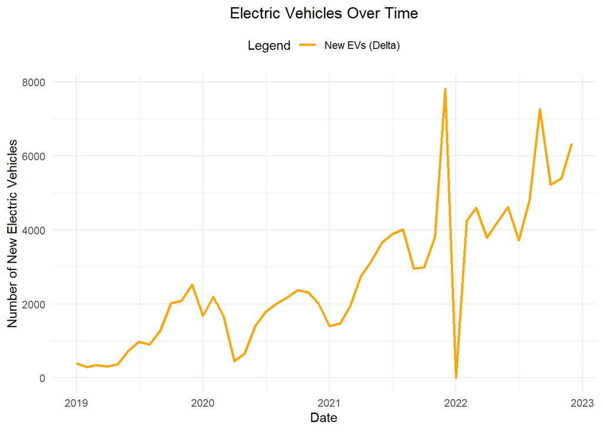

```r
fleet_df_BR %>%
  filter(year > 2018) %>%
  ggplot(aes(x = date)) +
  geom_line(aes(y = EVs_delta, color = "New EVs (Delta)"), size = 1) +
  labs(
    title = "Electric Vehicles Over Time",
    x = "Date",
    y = "Number of New Electric Vehicles",
    color = "Legend"
  ) +
  scale_color_manual(values = c("Total EVs" = "blue", "New EVs (Delta)" = "orange")) +
  theme_minimal() +
  theme(
    plot.title = element_text(hjust = 0.5),
    legend.position = "top"
  )
```

By using the `auto.arima()` function and specifying lack of seasonality in the data, it is possible to plot the projected variation in BEVs using the country’s aggregate data. In this case, I have extrapolated the data by 10 years, which yields very large confidence intervals, but allows for some level of forecasting.

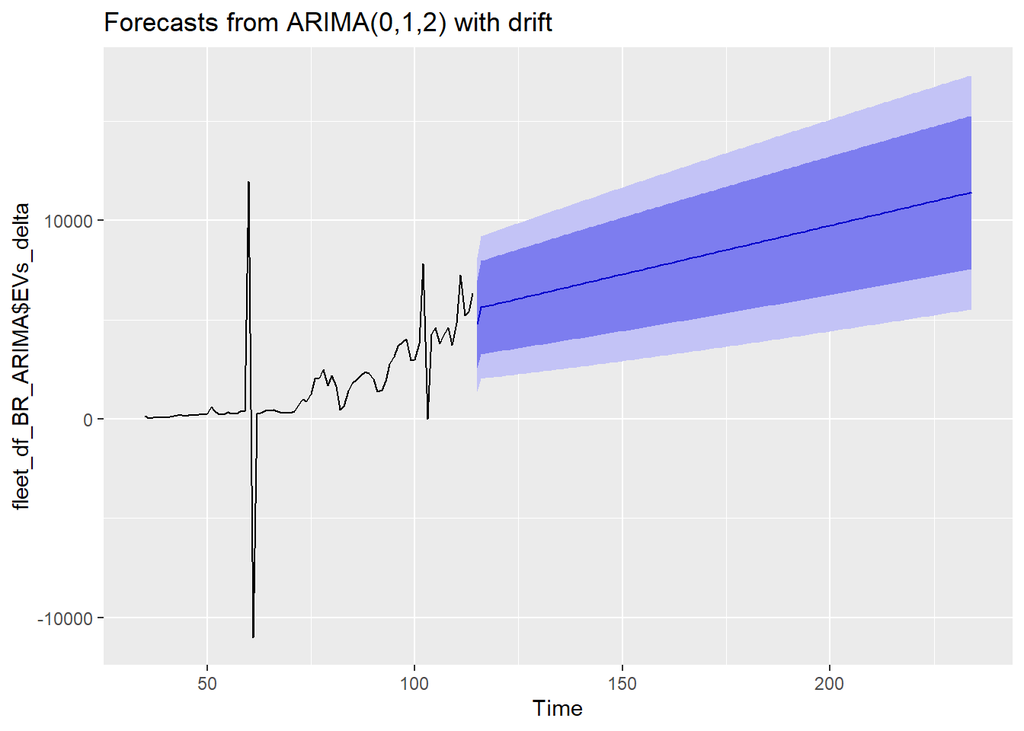

```r
fit <- auto.arima(fleet_df_BR_ARIMA$EVs_delta, seasonal = FALSE)

fit %>%
  forecast(h=120) %>%
  autoplot(include = 80)
```

I have used a different variable, `EVs_total`, which corresponds to the aggregate total fleet size of BEVs in a given month for all states, to project future values by using both ARIMA and ETS models.

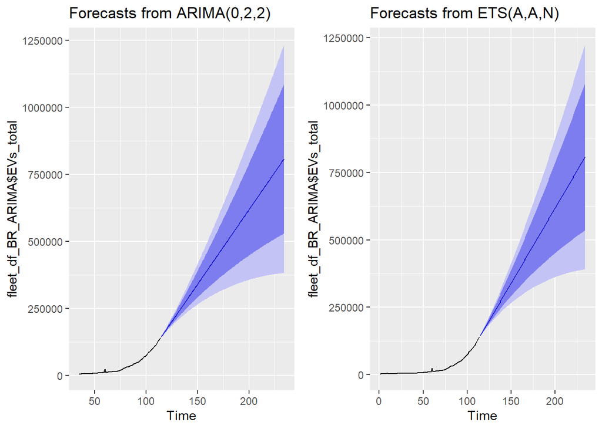

```r
## Using total values to run projections

## ARIMA Model
fit_arima <- auto.arima(fleet_df_BR_ARIMA$EVs_total, seasonal = FALSE)

plot_arima_total <- fit_arima %>%
  forecast(h=120) %>%
  autoplot(include = 80)

# ETS Model
fit_ets_total <- ets(fleet_df_BR_ARIMA$EVs_total)

plot_ets_total <- fit_ets_total %>%
  forecast(h=120) %>%
  autoplot()

# Comparing plot
gridExtra::grid.arrange(plot_arima_total, plot_ets_total, ncol =2)
```

These plots show that both approaches have similar performances. By choosing the ARIMA model, I have arrived at the following predicted values for the BEV stock in Brazil in 2032, considering the mean and upper/loan bounds of the confidence interval:

```r
projected_arima <- fit_arima %>%
  forecast(h=120)
```

**Upper bound:**

```r
tail(projected_arima$upper, 1)
```

```
Time Series:
Start = 234
End = 234
Frequency = 1
        80%     95%
234 1087557 1235292
```

**Mean:**

```r
tail(projected_arima$mean, 1)
```

```
Time Series:
Start = 234
End = 234
Frequency = 1
[1] 808480.6
```

**Lower bound:**

```r
tail(projected_arima$lower, 1)
```

```
Time Series:
Start = 234
End = 234
Frequency = 1
         80%      95%
234 529403.7 381669.4
```

While these projected values seem very large when comparing to the current stock of BEVs in Brazil, they would still represent a small share of the total fleet. Even the projected upper bound of 1.2 million vehicles, is still about 1% of the current total fleet of passenger cars of all kinds, amounting to about 123.5 million vehicles.

# 6 Next Steps

Based on the coefficients, statistical significance and R² values, the linear models obtained (with and without fixed effects) have shown a good performance. The corresponding tables suggest that the growth in BEV stock can be explained by population size, income levels, BEV prices. Additionally, Regularized Regressions and Multivariate Adaptive Regressions have been attempted, but the algorithms generated have not performed feature selection in a relevant way.

The next step now will be to to calculate and plot expected values of BEV stock for the coming years. For that, I will attempt two approaches:

1. Generate synthetic data by using the coefficients obtained to calculate projected values for the EV stock in the coming years;
2. Further explore different models (e.g. MARS, decision trees) and methods (e.g. ARIMA) to calculate projected values for the EV stock.

Afterwards, I will move to the second variable of the model, based on the OECD paper (2019); and will calculate the expected tax revenue impact of the further adoption of BEVs in the Brazilian market.